# genepro

#### Seurat workflow

Use `Seurat` package to **reduce dimensionality** and **clustering** of alignment score matrix.

`Seurat workflow` is composed of `CreateSeuratObject`, `FindVariableFeatures`, `ScaleData`, `RunPCA`,`FindNeighbors`,`FindClusters` and `RunUMAP` functions.

| Name of Functions | Function of Functions |
| --- | --- |
| `CreateSeuratObject` | Create a `Seurat` object from raw data (in this case: *alignment score matrix*) |
| `FindVariableFeatures` | Identifies features (in this case: *site*) that are outliers on a ‘mean variability plot’ |
| `ScaleData` | Scale and center the data |
| `RunPCA` | Principal Component Analysis (PCA) dimensionality reduction |
| `FindNeighbors` | Nearest-neighbor graph construction |
| `FindClusters` | Cluster Determination |
| `RunUMAP` | Uniform Manifold Approximation and Projection (UMAP) dimensional reduction. |

Because tSNE does not retain the global structure. Only the distance within the cluster is meaningful. However, the distance between cluster (the relationship between gene families) is our main concern. Therefore, tSNE method was not applied to data dimensionality reduction.

In addition, if you have an expression matrix for single-cell sequencing data, you can also use our process to directly cluster and reduce dimensionality of the data.

```r
##Seurat workflow
my_Seurat <- Seurat_workflow(alignment_score,dims_UMAP = 1:5,resolution = 0.05)
```

```
#> Modularity Optimizer version 1.3.0 by Ludo Waltman and Nees Jan van Eck
#>
#> Number of nodes: 1000
#> Number of edges: 23228
#>
#> Running Louvain algorithm...
#> Maximum modularity in 10 random starts: 0.9901
#> Number of communities: 7
#> Elapsed time: 0 seconds
```

```r
##Import metadata from data frame (annotation)
my_Seurat <- import_metadata(my_Seurat,Homeobox_small_annot)
```

Then, each sequence could be mapped to lower dimensional space.

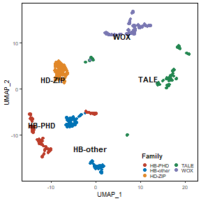

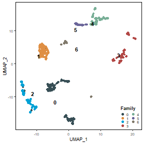

```r
require(ggsci)
require(ggplot2)
##Scatter plot
##Family
my_color1 <- pal_nejm(palette = "default")(5)

p1 <- cluster_scatter(my_Seurat,group = my_Seurat$Family,text_size = 3) +

      ##set color of each group
      scale_color_manual(values = my_color1) +

      ##set genepro custom theme
      theme_scatter(base_size = 7) +

      ##set position of legend
      theme(legend.position = c(1,0),legend.justification = c(1,0),

            legend.key.height = unit(0.2,"cm"),legend.key.width = unit(0.2,"cm")) +

      ##set number of column and point size of legends
      guides(color = guide_legend(ncol = 2,title = "Family",override.aes = list(size = 1.5)))

p1

##Cluster
my_color2 <- pal_jama(palette = "default")(7)

p2 <- cluster_scatter(my_Seurat,group = my_Seurat$seurat_clusters,text_size = 3) +

      scale_color_manual(values = my_color2) +

      theme_scatter(base_size = 7) +

      theme(legend.position = c(1,0),legend.justification = c(1,0),

            legend.key.height = unit(0.2,"cm"),legend.key.width = unit(0.2,"cm")) +

      guides(color = guide_legend(ncol = 2,title = "Family",override.aes = list(size = 1.5)))

p2
```

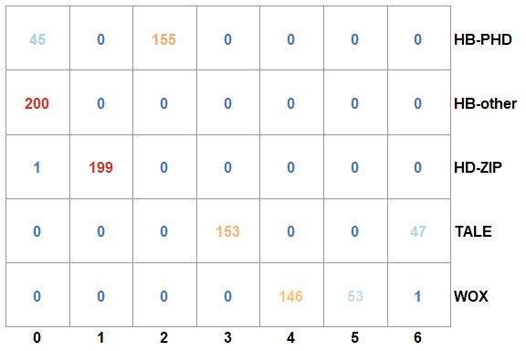

```r
require(grDevices)
require(RColorBrewer)

compare_classification <- table(my_Seurat$Family,my_Seurat$seurat_clusters)

my_color3 <- colorRampPalette(rev(brewer.pal(n = 7, name = "RdYlBu")))(101)

compare_classification_color <- my_color3[round(compare_classification / 2) + 1]

pheatmap(compare_classification,color = "white",legend = F,

         cluster_rows = F,cluster_cols = F,angle_col = 0,

         display_numbers = T,number_format = "%d",

         number_color = compare_classification_color,

         fontsize = 12,fontsize_number = 12,fontface = "bold")
```

In addition, you can easily use other grouping information, such as species classification and subfamily. Continuous variables are also supported, such as gene length.

```r
##Species classification

##Combine monocot, eudicot and Basal Magnoliophyta into angiosperms
table(my_Seurat$Taxonomic1)
```

```
#>
#> Basal Magnoliophyta           Bryophyta        Chlorophytae       Coniferophyta
#>                   6                   6                   3                  25
#>            Eudicots      Lycopodiophyta     Marchantiophyta            Monocots
#>                 689                   3                   4                 264
```

```r
my_Seurat$new_Taxonomic <- as.factor(my_Seurat$Taxonomic1)

levels(my_Seurat$new_Taxonomic)
```

```
#> [1] "Basal Magnoliophyta" "Bryophyta"           "Chlorophytae"
#> [4] "Coniferophyta"       "Eudicots"            "Lycopodiophyta"
#> [7] "Marchantiophyta"     "Monocots"
```

```r
levels(my_Seurat$new_Taxonomic)[c(1,5,8)] <- "Angiospermae"

levels(my_Seurat$new_Taxonomic)
```

```
#> [1] "Angiospermae"    "Bryophyta"       "Chlorophytae"    "Coniferophyta"
#> [5] "Lycopodiophyta"  "Marchantiophyta"
```

```r
my_color3 <- scale_color_manual(values = c("#DDDDDD",pal_nejm(palette = "default")(3)))

my_color3 <- c("#DDDDDD",pal_ucscgb(palette = "default")(5))

my_size <- ifelse(my_Seurat$new_Taxonomic == "Angiospermae",1,2)

p3 <- cluster_scatter(my_Seurat,group = my_Seurat$new_Taxonomic,

                      text_group = my_Seurat$Family,text_color = "#00000055",

                      size = my_size,text_size = 3) +

      theme_scatter(base_size = 7) + scale_color_manual(values = my_color3) +

      theme(legend.position = c(1,0),legend.justification = c(1,0),

            legend.key.height = unit(0.2,"cm"),legend.key.width = unit(0.2,"cm")) +

      guides(color = guide_legend(title = "Species",override.aes = list(size = 1.5)))

p3

##Combine Bryophyta, Chlorophytae, Coniferophyta, Lycopodiophyta, Marchantiophyta into Other plants

table(my_Seurat$Taxonomic2)
```

```
#>
#>            Asterids Basal Magnoliophyta           Bryophyta        Chlorophytae
#>                 151                   6                   6                   3
#>       Coniferophyta            Eudicots              Fabids      Lycopodiophyta
#>                  25                  67                 270                   3
#>             Malvids     Marchantiophyta            Monocots
#>                 201                   4                 264
```

```r
my_Seurat$new_Taxonomic2 <- as.factor(my_Seurat$Taxonomic2)

levels(my_Seurat$new_Taxonomic2)
```

```
#>  [1] "Asterids"            "Basal Magnoliophyta" "Bryophyta"
#>  [4] "Chlorophytae"        "Coniferophyta"       "Eudicots"
#>  [7] "Fabids"              "Lycopodiophyta"      "Malvids"
#> [10] "Marchantiophyta"     "Monocots"
```

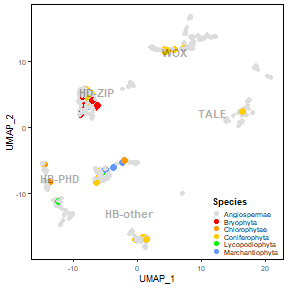

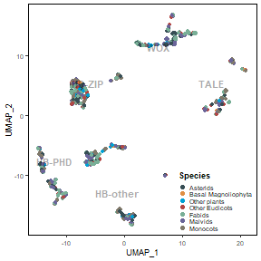

```r
levels(my_Seurat$new_Taxonomic2)[c(3,4,5,8,10)] <- "Other plants"

levels(my_Seurat$new_Taxonomic2)[4] <- "Other Eudicots"

my_color4 <- pal_jama(palette = "default")(7)

p4 <- cluster_scatter(my_Seurat,group = my_Seurat$new_Taxonomic2,

                      text_group = my_Seurat$Family,

                      text_color = "#00000055",text_size = 3) +

      theme_scatter(base_size = 7) + scale_color_manual(values = my_color4) +

      theme(legend.position = c(1,0),legend.justification = c(1,0),

            legend.key.height = unit(0.2,"cm"),legend.key.width = unit(0.2,"cm")) +

      guides(color = guide_legend(title = "Species",override.aes = list(size = 1.5)))

p4
```

```r
##WOX Subfamily

table(my_Seurat$WOX_subgroup)
```

```
#>
#>      Ancient Intermediate          WUS
#>           38           15          147
```

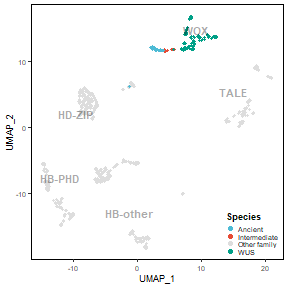

```r
my_color5 <- c("#DDDDDD",pal_npg(palette = "nrc")(3))

my_color5 <- my_color5[c(3,2,1,4)]

my_Seurat$WOX_subgroup[is.na(my_Seurat$WOX_subgroup)] <- "Other family"

p5 <- cluster_scatter(my_Seurat,group = my_Seurat$WOX_subgroup,

                      text_group = my_Seurat$Family,text_color = "#00000055",

                      text_size = 3,size = .8) +

      theme_scatter(base_size = 7) + scale_color_manual(values = my_color5) +

      theme(legend.position = c(1,0),legend.justification = c(1,0),

            legend.key.height = unit(0.2,"cm"),legend.key.width = unit(0.2,"cm")) +

      guides(color = guide_legend(title = "Species",override.aes = list(size = 1.5)))

p5
```

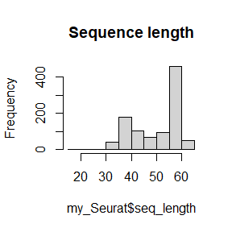

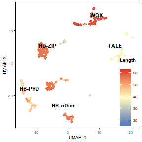

```r
##Gene length

##Calculate the length of each sequence
tmp_list <- strsplit(gsub(".*/","",rownames(Homeobox_small_annot)),split = "-")

my_Seurat$seq_length <- as.numeric(unlist(lapply(tmp_list,"[",2))) -

              as.numeric(unlist(lapply(tmp_list,"[",1))) + 1

midpoint <- sum(range(my_Seurat$seq_length)) / 2

hist(my_Seurat$seq_length,main = "Sequence length")

p6 <- cluster_scatter(my_Seurat,group = my_Seurat$seq_length,text = T,
                      text_group = my_Seurat$Family,text_size = 3) +

      scale_color_gradient2(low = "#4575B4",high = "#D73027",
                            mid = "#FEFEC0",midpoint = midpoint) +

      theme_scatter(base_size = 7) +

      theme(legend.position = c(1,0),legend.justification = c(1,0))+

      guides(color = guide_colourbar(title = "Length\n"))

p6
```

#### Monocle workflow

Use `monocle` package to **reduce dimensionality** and **pseudotime analysis** of alignment score matrix.

`monocle` object were imported from `Seurat` object which is created in the previous step.

`monocle workflow` is composed of `monocle_import`, `reduceDimension` and `orderCells` functions.

| Name of Functions | Function of Functions |
| --- | --- |
| `monocle_import` | Import a seurat object and convert it to a monocle object |
| `reduceDimension` | Dimensionality reduction |
| `orderCells` | Orders cells according to pseudotime |

```r
##Monocle workflow to get pseudotime and state of each sequence
require(monocle)

my_monocle <- monocle_workflow(my_Seurat)

table(my_monocle$State)
```

```
#>
#>   1   2   3   4
#> 217 191 393 199
```

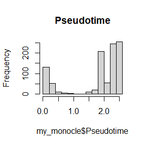

```r
hist(my_monocle$Pseudotime,main = "Pseudotime")
```

Then, each sequence could be mapped to lower dimensional space.

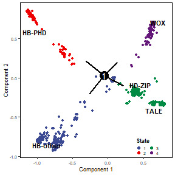

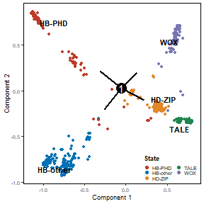

```r
##Colored by State
my_color7 <- pal_aaas(palette = "default")(4)

p7 <- cluster_scatter(my_monocle,group = my_monocle$State,

                      text_group = my_monocle$Family,text_size = 3) +

  theme_scatter(base_size = 7) +

  theme(legend.position = c(1,0),legend.justification = c(1,0),

        legend.key.height = unit(0.2,"cm"),legend.key.width = unit(0.2,"cm")) +

  scale_color_manual(values = my_color7) +

  guides(color = guide_legend(ncol = 3,title = "State",override.aes = list(size = 1.5))) +

  labs(x = "Component 1",y = "Component 2")

p7

##Colored by Family
p8 <- cluster_scatter(my_monocle,group = my_monocle$Family,

                      text_group = my_monocle$Family,text_size = 3) +

  theme_scatter(base_size = 7) +

  theme(legend.position = c(1,0),legend.justification = c(1,0),

        legend.key.height = unit(0.2,"cm"),legend.key.width = unit(0.2,"cm")) +

  scale_color_manual(values = my_color1) +

  guides(color = guide_legend(ncol = 2,title = "State",override.aes = list(size = 1.5))) +

  labs(x = "Component 1",y = "Component 2")

p8
```

#### Specific sites

Find Specific sites of each custom group in Seurat object. The custom group information must in the metadata of Seurat object.

If you have external grouping information, you can use the `import_metadata` function to import it into the Seurat object. You can also use `$` to directly add to the metadata of the Seurat object.

```r
##Group must in the metadata of Seurat object
colnames(my_Seurat@meta.data)
```

```
#>  [1] "orig.ident"       "nCount_RNA"       "nFeature_RNA"     "RNA_snn_res.0.05"
#>  [5] "seurat_clusters"  "Species"          "ID"               "Names"
#>  [9] "Family"           "Description"      "Taxonomic1"       "Taxonomic2"
#> [13] "Alias"            "Genome"           "WOX_subgroup"     "At_WOX"
#> [17] "new_Taxonomic"    "new_Taxonomic2"   "seq_length"
```

```r
##We chose 'Family' as costum group, identifying the specific site of each family
my_Specific_site <- find_Specific_site(my_Seurat,ident = "Family",logfc = 0,min.pct = 0)

head(my_Specific_site)
```

```
#>                 p_val avg_log2FC pct.1 pct.2     p_val_adj cluster    gene
#> site 32 6.674038e-202 0.17599874 0.940     0 7.675144e-200  HB-PHD site 32
#> site 31 6.856341e-202 0.25370071 0.935     0 7.884793e-200  HB-PHD site 31
#> site 28 4.527061e-201 0.20520717 0.935     0 5.206120e-199  HB-PHD site 28
#> site 33 9.577053e-201 0.08984424 0.940     0 1.101361e-198  HB-PHD site 33
#> site 27 1.049394e-200 0.18356255 0.935     0 1.206803e-198  HB-PHD site 27
#> site 26 2.339797e-200 0.23829866 0.930     0 2.690767e-198  HB-PHD site 26
```

Calculate conservation of each site in each family (group) then draw the heatmap.

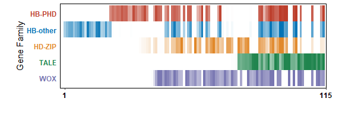

```r
##Get seq conservation (bits) of each site in each family (group)
my_seq_conservation <- get_seq_conservation(seqs = Homeobox_small_all$combined_alignment,

                                            group = my_Seurat$Family,type = "AA")
##Conservative heatmap for each site
p9 <- Position_site_heatmap(my_seq_conservation,group_color = my_color1) +

                            theme(plot.margin = margin(5,20,5,20))

p9
```

Display specific site of each family.

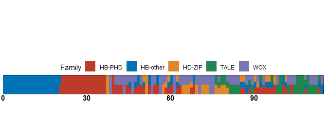

```r
##Specific site of each family
p10 <- Position_site_plot(dat = my_Specific_site,seurat = my_Seurat,

                          site_color = my_color1,plot_margin = margin(5,5,60,5))

p10
```